# Chapter 1: Statistical Foundations and Data Concepts

2026-02-25

# 1 Populations, Samples, and Parameters

## 1.1 Population vs Sample

A **population** is the entire group you want to study.  
A **sample** is a smaller, manageable subset drawn from that population for analysis.

> **Why sample?** Studying an entire population is often impractical or impossible. A well-chosen sample lets us draw conclusions about the population without measuring every member.

## 1.2 Parameters vs Statistics

| Term | Definition | Example |
| --- | --- | --- |
| **Parameter** | A numerical value that describes the *population* | Population mean μ |
| **Statistic** | A numerical value calculated from a *sample* | Sample mean x̄ |

Parameters are typically unknown; statistics are what we compute and use to *estimate* parameters.

## 1.3 Sampling Variability and Randomness

**Sampling variability** is the natural difference you see between statistics from different samples drawn from the same population. No two samples are exactly alike.

**Randomness** ensures that every member of the population has a fair, unbiased chance of being selected, which is what makes our sample representative.

# 2 Data Types and Structure

## 2.1 Categorical vs Numerical Data

- **Categorical data** — represents groups or labels (e.g., blood type, gender, country).
- **Numerical data** — represents measurable quantities (e.g., weight, temperature, salary).

## 2.2 Discrete vs Continuous Variables

| Variable Type | Description | Examples |
| --- | --- | --- |
| **Discrete** | Countable whole numbers; gaps exist between values | Number of students, coin flips |
| **Continuous** | Any value within a range; decimals allowed | Height, temperature, reaction time |

## 2.3 Measurement Scales

The scale of measurement determines what statistical operations are meaningful.

| Scale | Properties | Examples |
| --- | --- | --- |
| **Nominal** | Categories only; no order | Eye colour, gender |
| **Ordinal** | Ordered categories; differences not meaningful | Satisfaction level, class rank |
| **Interval** | Equal gaps; no true zero | Temperature in °C, calendar year |
| **Ratio** | Equal gaps + true zero | Weight, height, age |

> **Tip:** The higher the scale, the more statistical techniques you can apply. Ratio data supports the widest range of analyses.

# 3 R Foundations

## 3.1 Creating Data and Sampling with `sample()`

The most fundamental structure in R is the **vector** — an ordered collection of values of the same type.

```r
# Create a simple numeric vector using c()
x <- c(5, 10, 15, 20)
x
```

```
#> [1]  5 10 15 20
```

```r
# Draw 10 random numbers from 1–100 (with replacement)
# replace = TRUE allows the same number to appear more than once
set.seed(42)                          # set seed for reproducibility
sample_data <- sample(1:100, size = 10, replace = TRUE)
sample_data
```

[output not shown]

**Why `set.seed()`?** It fixes the random number generator so your results are reproducible — anyone running the same code gets the same output.

## 3.2 Basic Summaries with `summary()`

`summary()` gives you a five-number summary (plus the mean) in one call — a great first step when exploring new data.

```r
data <- c(12, 15, 20, 25, 30, 35, 40)

summary(data)
```

```
#>    Min. 1st Qu.  Median    Mean 3rd Qu.    Max.
#>   12.00   17.50   25.00   25.29   32.50   40.00
```

| Output | Meaning |
| --- | --- |
| Min. | Smallest value |
| 1st Qu. | 25th percentile |
| Median | Middle value (50th percentile) |
| Mean | Arithmetic average |
| 3rd Qu. | 75th percentile |
| Max. | Largest value |

## 3.3 Initial Exploratory Plots

Visualising data before formal analysis helps you spot patterns, outliers, and the overall shape of the distribution.

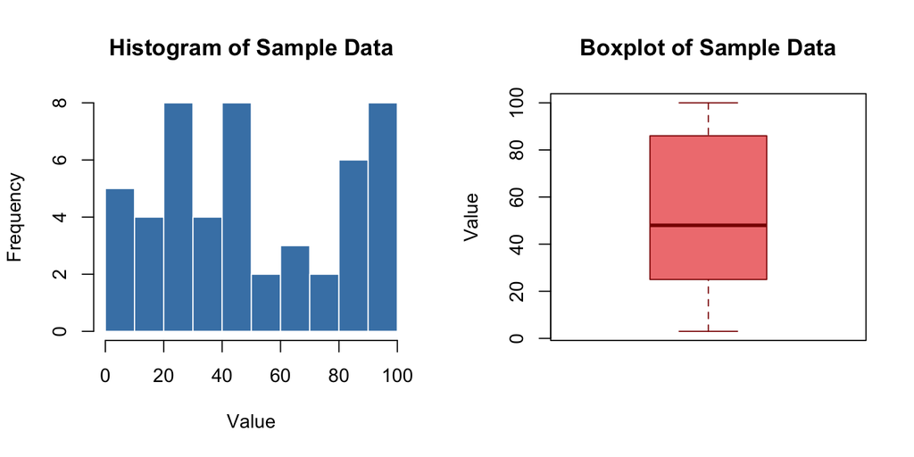

```r
set.seed(42)
data <- sample(1:100, size = 50, replace = TRUE)

# --- Side-by-side plots ---
par(mfrow = c(1, 2))

# Histogram: shows the frequency/distribution of values
hist(data,
     main  = "Histogram of Sample Data",
     xlab  = "Value",
     col   = "steelblue",
     border = "white")

# Boxplot: highlights median, spread, and potential outliers
boxplot(data,
        main   = "Boxplot of Sample Data",
        ylab   = "Value",
        col    = "lightcoral",
        border = "darkred")
```

```r
par(mfrow = c(1, 1))   # reset layout
```

### 3.3.1 What to look for

- **Histogram** — Is the distribution symmetric, skewed left, or skewed right? Any unusual gaps?
- **Boxplot** — Where is the median (centre line)? Are there points outside the whiskers (outliers)?

# 4 Chapter Summary

| Topic | Key Takeaway |
| --- | --- |
| Population vs Sample | Samples are used to make inferences about populations |
| Parameters vs Statistics | Parameters describe populations; statistics describe samples |
| Sampling Variability | Different samples from the same population yield different statistics |
| Data Types | Categorical (labels) vs Numerical (quantities) |
| Variable Types | Discrete (countable) vs Continuous (measurable) |
| Measurement Scales | Nominal → Ordinal → Interval → Ratio (increasing power) |
| R: `c()`, `sample()` | Build vectors and draw random samples |
| R: `summary()` | Quick five-number summary for any numeric vector |
| R: `hist()`, `boxplot()` | Core tools for initial visual exploration |